# Data Wrangling 2020 Steam Games with R

Pablo Rueda

16/8/2020

# Data Wrangling of 2020 Steam Games

## 1. Introduction

### 1.1. Introduction:

The [2020 Steam Games](https://www.kaggle.com/jesneuman/pc-games) was scrapped during July 2020, giving a total of 30250 games and 27 variables. In this project we will clean the data to make easier for the compunity to get insights from it.

1. Introduction  
   1.1. Introduction  
   1.2. Required packages  
   1.3. Custom functions
2. Data Wrangling  
   2.1. Preparation  
   2.2. Processing raw data  
   2.3. Prunning cases
3. Visualization  
   3.1. Number of games  
   3.2. Presence  
   3.3. Rating
4. Summary

### 1.2. Required packages:

```
library(tidyverse)    # Includes: dplyr for data manipulation,
                      # stringr for strings and
                      # ggplot2 for visualization
library(stringi)      # string manipulation (using functions not included in stringr)
library("gridExtra")  # support package for plots (+ ggplot2)
```

### 1.3. Custom functions:

**a) Analyse Missing Values:**  
We will use the `missval_df()` function original created by [Trishul Gowda](https://rpubs.com/trishul/final_project). This function inputs the blank string cells as missing values. Then, it counts the number of missing values per column and take it percentage.

```
missval_df<-function(df){
  df[df == ""] <- NA
  mv<-sapply(df, function(x) sum(is.na(x)))
  miss_tab<-c("Variable"="abc", "Missing_values" = 1, "Missing_percentage"=1)
  for(z in seq_along(df)){
    Variable<-colnames(df[z])
    tv<-nrow(df)
    Missing_values<-as.numeric(mv[z])
    per<-Missing_values/tv*100
    Missing_percentage<-round(per, digits = 2)
    row_n<-cbind(Variable, Missing_values, Missing_percentage)
    miss_tab<-rbind(miss_tab, row_n)
  }
  print(t(miss_tab[-1,]))
}
```

**b) Split multiple response variables:**  
There are some multicategorical variables which summary multiple options per case. For example, a game genre can be both Action and Adventure. We will define a function to split these categories in new rows.

```
splitColumn <- function(data){
  X = data
    ## 1. Control Missing Values:
  X$Control_NA <-           # Create a variable for missing data
  data[,c(2)]  %>%          # use the second column
  lapply(`==`, "") %>%      # check if row = "" (empty string)
  as.numeric                # convert to numeric (FALSE = 0, TRUE = 1)
    ## 2. Create boolean categories variables (e.g. Genre Action = Yes (1)/No(0))
      ### 2.1. Split:
  X <- data.frame(X,        # unify with the  data frame
    data[,c(2)] %>%         # Take the column from the data frame,
    stri_split_fixed(", ",  # Split by commas ", "
                     simplify = TRUE,
                     fill=T))
      ### 2.2. Extract the categories / col. labels:
  xLabels <-  X[4:length(X)] %>%
    t %>%                   # Transpose the new columns
    c %>%                   # Create a new vector with the labels
    unique()                # Extract the unique values
  xLabels = xLabels[!xLabels == ""] # remove NaN since we already have it

      ### 2.3. Creating the new variables per category:
  initial_cols = length(X) #temp. variable: original nº of columns
  for(i in 1:length(xLabels)){ #loop throught the categories (read upside-down)
    X[(ncol(X)+1)] <- +(Reduce(`|`, # Reduce with "Or" operator. If any TRUE, will be true
                            lapply(X[,c(3:initial_cols)], # Apply to all columns
                            `==`, xLabels[i])   # transform to boolean where = label / category is true
    ))
  }
      ### 2.4. Rename columns, remove unnecesary columns:
  X = drop(X[,c(1,3,(initial_cols+1):length(X))]) #remove unnecesary columns based on temp. variable
  colnames(X) <- c("id","Control_NA",xLabels)
    ## 3. Return:
  return(X)
}
```

**c) Extract digit:**  
Simple function to extract the numbers from a string vector and return it as vector of numbers.

```
extractDigit <- function(data){
  X <- data %>%
        str_extract("(\\d+)\\.*\\d*")  %>%  # Take the element of the string
        as.numeric                  # convert the element to numeric
  return(X)
}
```

**d) Ratings Breakdown:**  
We will clean later the RatingsBreakdown variable. This variable contains strings with the possible rates (“exceptional”,“recommended”, “meh”) and the number of players who rated the game with it.

The below function use two inputs, the vector to extract the rate, and the rate we want to extract(e.g. “exceptional:”). It returns a vector of digits with the number of people who rated the games with the input string.

```
takeRate <- function(dataToSplit, stringUsed) {
  rgexp = paste(stringUsed,"\\d*", sep=" ") #create a regular expression "str + number"
  output <- dataToSplit  %>%  # Take the data
            as.character %>%  # convert to string
            strsplit(",") %>% # Split by commas (now, we'll have the possible answers in the data)
            str_extract(rgexp) %>%   # Apply the string to extract only the input answer
            str_extract(" \\d*") %>% # extract the numerical element
            as.numeric
  return(output)
}
```

**e) Grouped information:**

Custom function to extract some key variables information grouped by binary variables.

```
binaryGrouping <- function(split_df,df) {
  split_df <- split_df[split_df$id %in% df$id,]
  groupedDta <- data.frame( # empty data frame to fill
    GroupingVar=character(),
    N_Games=integer(),
    critic_mean=integer(),
    critic_sd=integer(),
    cost_mean=integer(),
    cost_sd=integer(),
    TotalPresence=integer(),
    MedianPresence=integer(),
    rate_exceptional=integer(),
    rate_recommended =integer(),
    rate_meh = integer(),
    stringsAsFactors=FALSE)

  ## 1.1.2 Iteration throught the grouping variables
  for( i in 2:ncol(split_df)){
    j = i -1
    groupedDta[j, 1] = colnames(split_df)[i] #Column names
    groupedDta[j, 2] = sum(split_df[,i])
    ### metacritic data:
    groupedDta[j, c(3,4)] = df %>%
      filter(split_df[,i] == 1) %>%                     # filter, "genre true"
      summarise_at(vars(Metacritic),              # column to analyse
                   list(mean = mean, deviation =  sd),  # function to use
                   na.rm= TRUE)
    ### Costs:
    groupedDta[j, c(5,6)] = df %>%
      filter(split_df[,i] == 1) %>%
      summarise_at(vars(cost),
                   list(mean = mean, deviation =  sd),  # costs mean and deviation
                   na.rm= TRUE)
    ### Total Presence:
    groupedDta[j, c(7)] = df %>%
      filter(split_df[,i] == 1) %>%
      summarise_at(vars(Presence),   # presence = number of players
                   list(sum = sum),
                   na.rm= TRUE)
    ### Median Presence:
    groupedDta[j, c(8)] = df %>%
      filter(split_df[,i] == 1) %>%
      summarise_at(vars(Presence),   # presence = number of players
                   list(median = median),
                   na.rm= TRUE)
    ### Rate:
    groupedDta[j, c(9)] = df %>%
      filter(split_df[,i] == 1) %>%
      summarise_at(vars(rate_exceptional),   # rate_exceptional = number of people giving "exceptional"
                   list(sum = sum),          # since, it is number of people, we sum it to know the amount
                   na.rm= TRUE)
    groupedDta[j, c(10)] = df %>%
      filter(split_df[,i] == 1) %>%
      summarise_at(vars(rate_recommended),   # rate = recommended
                   list(sum = sum),
                   na.rm= TRUE)
    groupedDta[j, c(11)] = df %>%
      filter(split_df[,i] == 1) %>%
      summarise_at(vars(rate_meh),   # rate = meh
                   list(sum = sum),
                   na.rm= TRUE)
  }
  groupedDta$Steam_Rate <- (groupedDta$rate_exceptional*10 + groupedDta$rate_recommended*7.5 + groupedDta$rate_meh*1)/(groupedDta$rate_exceptional+groupedDta$rate_recommended+groupedDta$rate_meh)
  return(groupedDta)
}
```

## 2. Data Wrangling

### 2.1. Preparation

**1. Import the data:**  
The data can be downloaded at [2020 Steam Games](https://www.kaggle.com/jesneuman/pc-games). Once it is downloaded, it can be imported using `df <- read.csv("./games.csv")`

**2. Defining the data:**  
Use `colnames(df); glimpse(df); missval_df(df)` to analyse the variables and extract some initial insights. Below are some insights extracted from the application of the previous functions:

- **ID variables:** There are 5 variables to identify the case (X, id, Name, SteamURL and RawgID). “Name” and “RawgID” have a 0.31% of missing data, for further analysis we will only keep “id” (with no NAs). If the game belong to a franchise, the Franchise (83.18% NAs) variable shows which franchise it belong to.
- **Definitions:** There are some variables which are used to define the game. These variable are multiple response variables (Genres, Tags and players), and binary ([Indie](https://en.wikipedia.org/wiki/Indie_game)) and strings (Description), which will not be added on this cleaning.
- **Rating:** Metacritic (88.91% NAs) contains the numeric game rating in the [Metacritic](https://www.metacritic.com/) platform. While RatingsBreakdown (50.27% NAs) contains a string per game with the steam rates and the number of players who rated this way(e.g. “recommended: 882, meh: 501, exceptional: 283, skip: 185”).
- **Requirements:** There are 4 variables used to define the game requirements. Storage (9.12% NAs) and Memory (6.39% NAs) define the Storage and RAM requirements of the game in a string format with the numeric requirement and it unit (MB or GB). Platform (0.42% NAs) are the platforms where the game can be played. Graphics (14.22% NAs) contains the Graphics requirement for PC in string format (no visible pattern at first sigh).
- **Characteristics:** Other variables not grouped are:
  - *Presence* (0.31% NAs) are the number of people who played/download the game.
  - *ReleaseDate* (10.66% NAs) is when the game was launched.
  - *Soundtrack* (0.68% NAs) is a binary variable which represents “whether or not the game was noted for its soundtrack” (see kaggle data context).
  - *OriginalCost* (2.47% NAs) is a string with the cost of the game (in dollars) or if it is “Free”/“Free to play”, while *DiscountedCost* is the cost with a string with the costs of the games which had discounts.
  - *Controller* (0.91% NAs) binary variable representing whether if the game can or not be played with external controllers.
  - *Languages* (0.74% NAs) string with multiple responses about the languages to which the game has been translated.
  - *ESRB* (84.31% NAs), string with age and content rating.
  - *Achievements* (0.31% NAs), number of achievements that can be get in the game.
  - *Publisher* probably would be the game developer company, but since it is has a 100% of missing values, it will be dropped.

### 2.2. Processing raw data

#### Definitions

There are some variables which are used to define the game. These variable are multiple response variables (Genres and Tag), binary ([Indie](https://en.wikipedia.org/wiki/Indie_game)) and strings (Description), which will not be added on this cleaning.

As we have seen in the Preparation, there are some variables used to define the game. In this section, these variables will be processed, revised and prepared for further analysis.

##### **1. Genres:**

Apply the `SplitColumn()` custom function to genres, rename the NAs to a new column for possible analysis and check the total amount of games per genres.

```
genres <- splitColumn(df[c(2,which(colnames(df) == "Genres"))]) # Extract the genres
colnames(genres)[2] <- "Genre_NA" # Remember, second column is a NAs tracker
colSums(genres[,-1])  # category with extremely low cases
genres = genres[,-c(2,4,8,11)] # NA, Free to Play, Indie, Early access
colnames(genres)
```

```
##              Genre_NA                Action          Free to Play
##                  2968                 11771                  1884
##             Adventure Massively Multiplayer                   RPG
##                 10630                   848                  4903
##                 Indie            Simulation              Strategy
##                 19706                  5088                  5836
##          Early Access                Racing                Sports
##                  2516                  1060                  1169
##                Casual                 Movie               Violent
##                 10177                     1                     1
##                  Gore      Audio Production             Education
##                     1                     2                     1
##     Software Training             Utilities Design & Illustration
##                     1                     2                     1
```

##### **2. Players:**

Apply the `SplitColumn()` custom function to split players.

```
nplayers <- splitColumn(df[c(2,which(colnames(df) == "Players"))]) # Extract the type of game by players
colnames(nplayers)[2] <- "nplayers_NA"
```

##### **3. Tags:**

Apply the `splitColumn()` function to tags. We can see that it gives a dataframe with 428 columns (use `length(tags)`. We reduce the dataframe filtering the tags with a low amount of games (less than 500 games), but there are still 117 tags. To understand a bit more about these tags, we will compute the name of the first 15 tags.

[output not shown]

- Not considered genres:

```
tags<-tags[ , -which(names(tags) %in% c( colnames(genres[,-1])))]
colnames(tags)
genre_tags <- c(2,3,6,22,23,27,28,32,34,35,38,40,44:46,53,55:58,66,
                67,71,76:78,80,85,90:92,94,97,99,100,103,104)

genres <- data.frame(genres,tags[,genre_tags])
tags <- tags[,-genre_tags]
```

- The players relation:

```
nplay_tags <- c(2,3,5:7,24,29:31)
nplayers <- data.frame(nplayers,tags[,nplay_tags])
tags <- tags[,-nplay_tags]
```

- The setting of the game (e.g. war, fantasy, sci-fi…):

```
setting <- tags[,c(1,3,5,8:10,14,26,27,29,31,33,35,40,50)]
tags<-tags[,-c(3,5,8:10,14,26,27,29,31,33,35,40,50)]
```

- The visual elements of the game (e.g. first person, 2D, pixel, retro,…):

```
visual <- tags[,c(1,2,8,12,20,22,26,29,31,33:35,38:40,42:44)]
tags<-tags[,-c(2,8,12,20,22,26,29,31,33:35,38:40,42:44)]
```

- The game features:

```
features <- tags[,c(1,2,7,8,22,24:29)]
tags<-tags[,-c(2,7,8,22,24:29)]
```

#### Rating

##### **1. RatingsBreakdown:**

The RatingsBreakdown can be used based in the number of people who rated the game, or creating a new rating system based on it.  
To extract the number of people who rated the game with an specific label, we apply the `takeRate()` function with the rating labels as inputs.

```
rating <- data.frame(
id = df$id,
rate_meh = takeRate(df$RatingsBreakdown,"meh:"),
rate_recommended = takeRate(df$RatingsBreakdown,"recommended:"),
rate_exceptional = takeRate(df$RatingsBreakdown,"exceptional:"))
```

Now we have three variables with the number of people who rated each game as “exceptional”, “recommended” or “meh”. By giving numerical values to these labels, we can compute a pseudo-rate. We only have to multiply each variable -number of respondents- to the numerical value of the label (e.g. exceptional = 10; recommended = 7.5; and meh = 1), and divide it by the total amount of respondents (sum of the 3 raw variables):

```
rating[is.na(rating)] <- 0 # if we keep NAs, the results will be NA whenever not all the 3 columns are filled
rating$Steam_Rate <- (rating$rate_exceptional*10 + rating$rate_recommended*7.5 + rating$rate_meh*1)/(rating$rate_exceptional+rating$rate_recommended+rating$rate_meh)
```

With this formula, whenever a game was not rated by any user it gives Missing Values (since the calulation would involve a division by zero).

##### **2. Metacritic:**

[Metacritic](https://www.metacritic.com/) is one of the variables with higher amount of missing values. Since it is a critic platform, we can’t assume random missing values, so we will keep Metacritic and create a new variable (Metacritic_NA) which could be used for further analysis.

```
rating$Metacritic <- df$Metacritic
rating$Metacritic_NA <- is.na(df$Metacritic)
```

#### Requirements

##### **1. Storage Requirements**

Create a working dataframe. Since storage can be in different units (MB and GB), we’ll exctract the difit and the storage unit:

```
requirements = df[,c("id","Storage")]
requirements$storageDigit <-  extractDigit(requirements[,2]) # Take the digit
num_col = ncol(requirements)                       # Save the position the last column
requirements$storageUnit = str_extract(requirements[,2],"[[:alpha:]]B")  # Extract the storage unit
```

Based on the unit, create a new factor column which we will multiply to the digit. After it, we will apply the factor creating a Storage in GB column.

```
requirements$factor <-  ifelse(requirements$storageUnit == "MB",1/1024,  # extract factor based on unit
                        ifelse(requirements$storageUnit == "GB",1, NA))
requirements$Storage_GB = round(requirements$storageDigit*requirements$factor,
                                2) #apply the factor
requirements <- requirements[,c(1,6)] # used columns
```

##### **2. RAM Requirements**

Apply the `extractDigit()` function to extract RAM requirements:

```
requirements$RAM_GB <- extractDigit(df[,"Memory"])
```

##### **3. Platform**

Since this database doesn’t contain games which are not in steam, it would be biased to analyse the games only based on the platforms. Rather than that, we are going to keep a control variable to know if the games are multiplatform or not.

```
requirements$Platform <- df[,"Platform"]
requirements$Multiplatform <- +(nchar(as.character(df[,"Platform"]))>3)
```

##### **4. Graphics**

```
requirements$Graphics <- df$Graphics
```

#### Characteristics

There are multiple characteristics which can be used in future analysis. Some variables (Presence,ReleaseDate,Soundtrack… ) were already added. Below are the columns which require preparation before been merged to the working dataframe.

##### **1. Cost:**

The cost variable contains strings with the numeric amount required to pay the game and character strings with “Free” or “Free to play” when the cost is 0. So, we require:

- To extract the digit,
- extract the “Free” string,
- convert “Free” to numerical zero “0”

```
costs = data.frame(id=df$id , costPre = df$OriginalCost) # create a working data frame
costs$costExtract = str_extract(costs$costPre,"(\\d*[[:punct:]]\\d*)|(Free)") # extract costs
costs$cost <- costs$costExtract %>%                   # add costs
          sapply(function(x) x == "Free") %>% # check if costs is string "Free"
          ifelse(0,costs$costExtract) %>%            # if cost string is "Free", the cost will be 0; else, it will be the digit
          as.numeric                          # convert to numeric
costs <- costs[,c(1,4)]
```

##### **2. Languages:**

First, we apply the `SplitColumn()` to the Languages. Then, we sum the amount of languages in a new variable (nLanguages) to control to how many languages was a game translated.

```
langu <- splitColumn(df[c(2,which(colnames(df) == "Languages"))]) # Extract the languages
langu$nLanguages = rowSums(langu[,-c(1,2)]) # number of languages available
```

#### Merge and Save

The last step of processing the raw data we will reduce the amount of data frames to share. To do so, we will merge some of the datasets which refeer to similar variables and save the data frames to share them:

```
clean_df <- df[,c(2,3,4,5,8,9,15,21,23,24,26)]
clean_df<- clean_df %>%
  merge(costs, by="id") %>%
  merge(rating, by="id") %>%
  merge(requirements, by="id")%>%
  merge(tags[,c(1,8)], by="id") #early access

game_descriptors<- genres %>%
  merge(setting, by="id") %>%
  merge(visual, by="id") %>%
  merge(nplayers, by="id")

rm(costs,rating,requirements)
rm(genres,setting,visual,nplayers)

write.csv2(game_descriptors, file = "g_descriptors.csv")
write.csv2(langu, file = "g_languages.csv")
write.csv2(features, file = "g_features.csv")
```

If we require the data to be merged in a single dataset we can merge it with:

```
clean_df<- clean_df %>%
  merge(game_descriptors, by="id") %>%
  merge(langu, by="id") %>%
  merge(features, by="id")
write.csv2(clean_df, file = "g_merged.csv")
```

### 2.3. Prunning cases

- **Missing values:**

We can analyse the missing values in the data frames using the `missval_df()` function.

```r
missval_df(clean_df)
```

```
##
## Variable           "id" "Name" "RawgID" "SteamURL" "Indie" "Presence"
## Missing_values     "0"  "94"   "94"     "55"       "205"   "94"
## Missing_percentage "0"  "0.31" "0.31"   "0.18"     "0.68"  "0.31"
##
## Variable           "ReleaseDate" "Controller" "ESRB"  "Achievements"
## Missing_values     "3226"        "274"        "25503" "94"
## Missing_percentage "10.66"       "0.91"       "84.31" "0.31"
##
## Variable           "Description" "cost" "rate_meh" "rate_recommended"
## Missing_values     "219"         "1046" "0"        "0"
## Missing_percentage "0.72"        "3.46" "0"        "0"
##
## Variable           "rate_exceptional" "Steam_Rate" "Metacritic" "Metacritic_NA"
## Missing_values     "0"                "16241"      "26894"      "0"
## Missing_percentage "0"                "53.69"      "88.91"      "0"
##
## Variable           "Storage_GB" "RAM_GB" "Platform" "Multiplatform" "Graphics"
## Missing_values     "2852"       "1951"   "127"      "0"             "4302"
## Missing_percentage "9.43"       "6.45"   "0.42"     "0"             "14.22"
##
## Variable           "Early Access"
## Missing_values     "0"
## Missing_percentage "0"
```

We can see that there are a 94 of missing values in Name, RawgID and Presence. Using the below function we can also see how the NAs in both columns are the same:

```r
identical((clean_df$Name == ""),
          (is.na(clean_df$Presence)))
```

```
## [1] TRUE
```

These cases can be games not fully realeased when the data was collected, so we will remove them to avoid bias.

```r
clean_df<-clean_df[!is.na(clean_df$RawgID),]
```

- **Early access:**  
  Other variable to remove are those games which where in early access during the data collection:

```r
clean_df<-clean_df[!clean_df$`Early Access`,]
clean_df <- clean_df[,-24]
```

- **Anomaly in presence:**  
  There are some games which presence is 0, but it is suspcious that there are games which were not tested by anyone. These games could be unrealised games, or games which gave errors during the data collection, so we will remove these games from the set:

```r
clean_df<-clean_df[!(clean_df$Presence==0),]
```

- **Remove duplicated:**  
  Using `sum(duplicated(clean_df$RawgID))` we can see how there are 2216 duplicated rows in the dataset, using the distinct function and the RawgID of the games, we will remove the duplicated games:

```r
clean_df<-clean_df %>%
  distinct(RawgID, .keep_all = TRUE)
```

After prunning the problematic cases from the dataset we have a dataset ready to be used for furhter analysis:

```
write.csv2(clean_df, file = "g_df.csv")
```

## 3. Visualizations

We will use the define `binaryGrouping()` function to extract information based on some of the game descriptors:

### 3.1. Number of Games

Here we can see the number of games per genre, setting or visual characteristics:

#### Genres

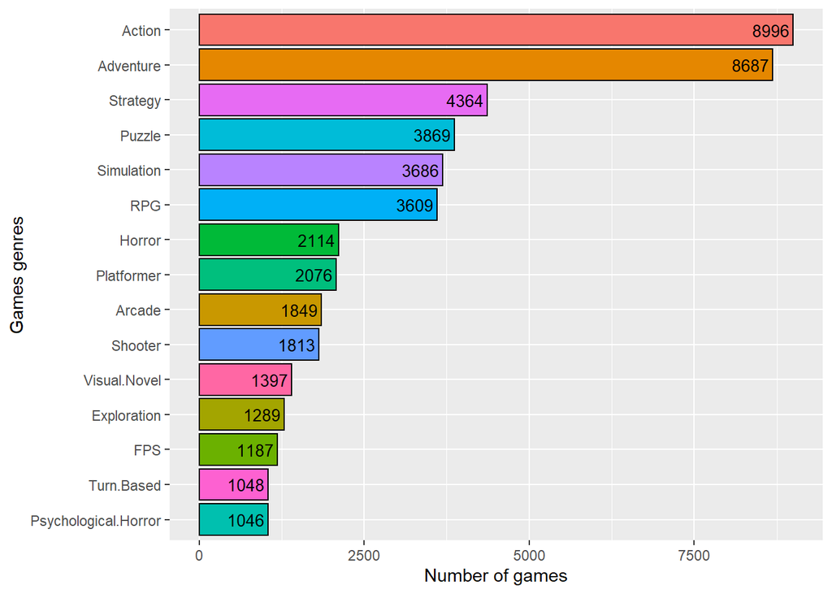

```r
game_descriptors[,c(1:9,18:54)] %>%
binaryGrouping(clean_df) %>%
arrange(desc(N_Games)) %>%
slice(1:15) %>%
  ggplot(aes(x=reorder(GroupingVar, N_Games), y=N_Games, fill=GroupingVar)) +
  geom_bar(colour="black", stat="identity")+
  geom_text(aes(label=round(N_Games,2)), vjust=0.5,hjust=1.1, color="Black", size=3.5)+
  theme(legend.position="none")+
coord_flip() + xlab("Games genres") + ylab("Number of games")
```

#### Setting

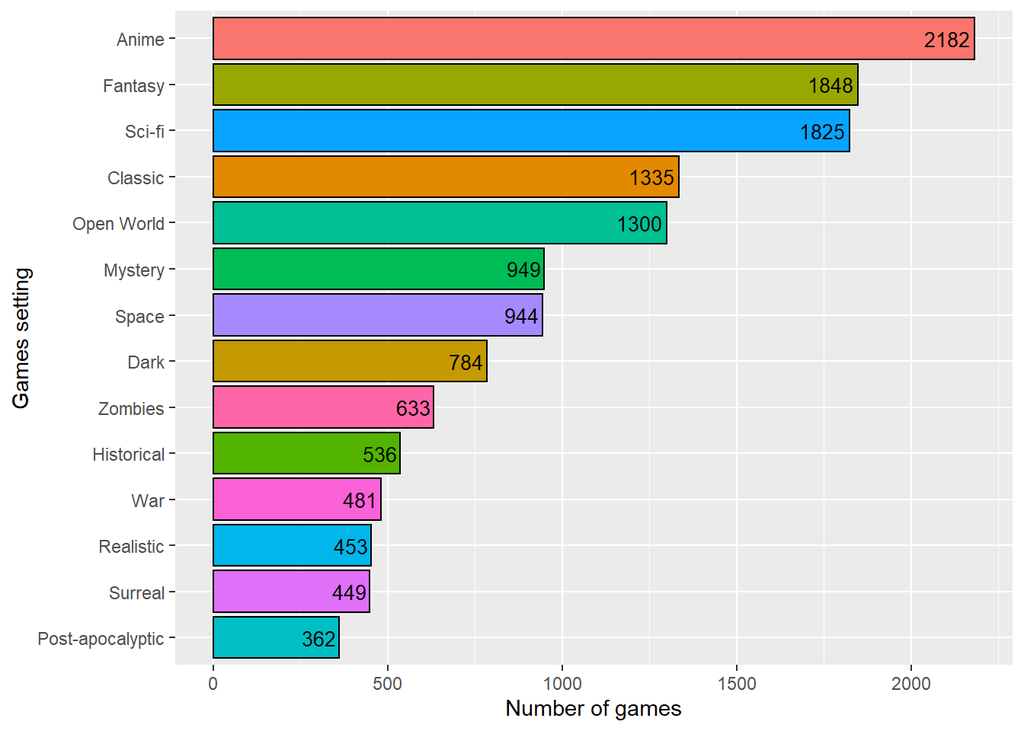

```r
game_descriptors[,c(1,56:69)] %>%
binaryGrouping(clean_df) %>%
arrange(desc(N_Games)) %>%
slice(1:15) %>%
  ggplot(aes(x=reorder(GroupingVar, N_Games), y=N_Games, fill=GroupingVar)) +
  geom_bar(colour="black", stat="identity")+
  geom_text(aes(label=round(N_Games,2)), vjust=0.5,hjust=1.1, color="Black", size=3.5)+
  theme(legend.position="none")+
coord_flip() + xlab("Games setting") + ylab("Number of games")
```

#### Style

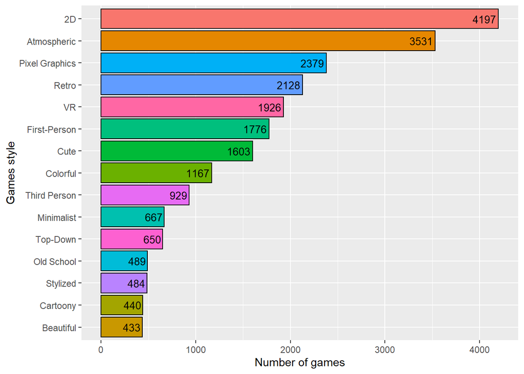

```r
game_descriptors[,c(1,70:86)] %>%
binaryGrouping(clean_df) %>%
arrange(desc(N_Games)) %>%
slice(1:15) %>%
  ggplot(aes(x=reorder(GroupingVar, N_Games), y=N_Games, fill=GroupingVar)) +
  geom_bar(colour="black", stat="identity")+
  geom_text(aes(label=round(N_Games,2)), vjust=0.5,hjust=1.1, color="Black", size=3.5)+
  theme(legend.position="none")+
  coord_flip() + xlab("Games style") + ylab("Number of games")
```

#### Other features

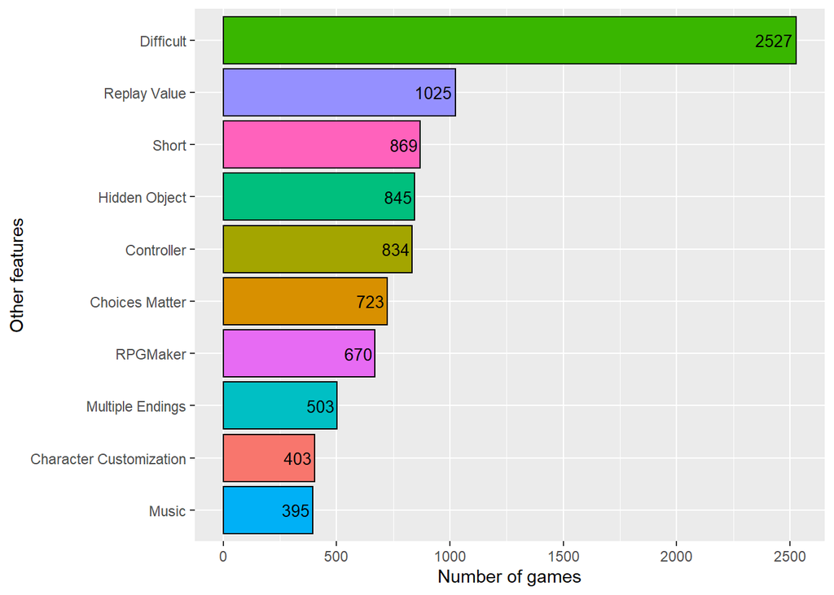

```r
features %>%
binaryGrouping(clean_df) %>%
arrange(desc(N_Games)) %>%
slice(1:15) %>%
  ggplot(aes(x=reorder(GroupingVar, N_Games), y=N_Games, fill=GroupingVar)) +
  geom_bar(colour="black", stat="identity")+
  geom_text(aes(label=round(N_Games,2)), vjust=0.5,hjust=1.1, color="Black", size=3.5)+
  theme(legend.position="none")+
  coord_flip() + xlab("Other features") + ylab("Number of games")
```

#### Languages

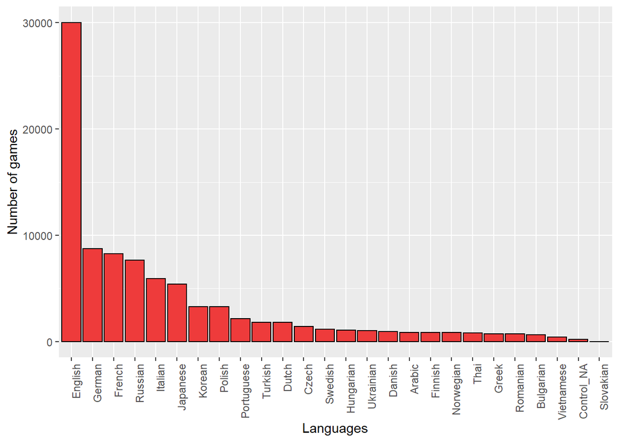

```r
data.frame(Country = colnames(langu[,-c(1,28)]), nGames=colSums(langu[,-c(1,28)])) %>%
ggplot( aes(x=reorder(Country, -nGames), y=nGames)) +
  geom_bar(colour="black", stat="identity", fill="brown2")+
  xlab("Languages") + ylab("Number of games")  + theme(axis.text.x=element_text(angle=90,hjust=1))
```

### 3.2. Presence

Here we can see the presence based on the previous mentioned characteristics. Since the total sum of the games presence of a genre can be biased, we will display it near to the median presence of the games in the categories:

#### Genres

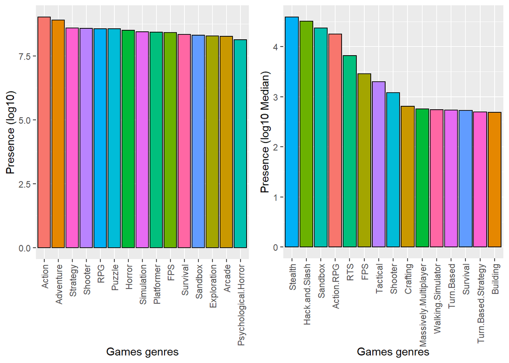

```r
p1<-game_descriptors[,c(1:9,18:54)] %>%
  binaryGrouping(clean_df) %>%
  arrange(desc(TotalPresence)) %>%
  slice(1:15) %>%
    ggplot(aes(x=reorder(GroupingVar, -TotalPresence), y=log10(TotalPresence), fill=GroupingVar)) +
    geom_bar(colour="black", stat="identity")+
  theme(axis.text.x = element_text(angle = 90, vjust = 0.5, hjust=1), legend.position="none")+
    xlab("Games genres") + ylab("Presence (log10)")

p2<-game_descriptors[,c(1:9,18:54)] %>%
  binaryGrouping(clean_df) %>%
  arrange(desc(MedianPresence)) %>%
  slice(1:15) %>%
    ggplot(aes(x=reorder(GroupingVar, -MedianPresence), y=log10(MedianPresence), fill=GroupingVar)) +
    geom_bar(colour="black", stat="identity")+
  theme(axis.text.x = element_text(angle = 90, vjust = 0.5, hjust=1), legend.position="none")+
    xlab("Games genres") + ylab("Presence (log10 Median)")

grid.arrange(p1, p2, nrow = 1)
```

#### Setting

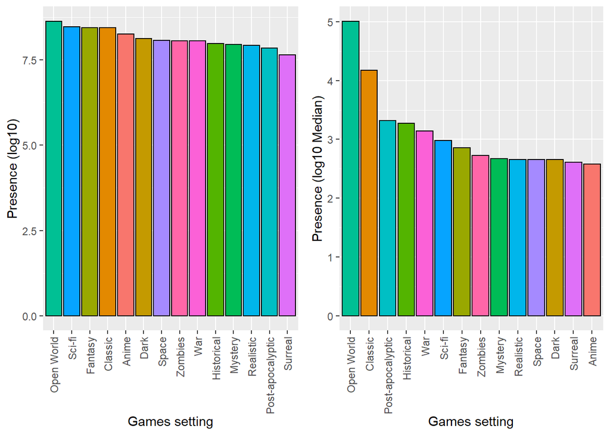

```r
p1<-game_descriptors[,c(1,56:69)] %>%
  binaryGrouping(clean_df) %>%
  arrange(desc(TotalPresence)) %>%
  slice(1:15) %>%
    ggplot(aes(x=reorder(GroupingVar, -TotalPresence), y=log10(TotalPresence), fill=GroupingVar)) +
    geom_bar(colour="black", stat="identity")+
  theme(axis.text.x = element_text(angle = 90, vjust = 0.5, hjust=1), legend.position="none")+
    xlab("Games setting") + ylab("Presence (log10)")

p2<-game_descriptors[,c(1,56:69)] %>%
  binaryGrouping(clean_df) %>%
  arrange(desc(MedianPresence)) %>%
  slice(1:15) %>%
    ggplot(aes(x=reorder(GroupingVar, -MedianPresence), y=log10(MedianPresence), fill=GroupingVar)) +
    geom_bar(colour="black", stat="identity")+
  theme(axis.text.x = element_text(angle = 90, vjust = 0.5, hjust=1), legend.position="none")+
    xlab("Games setting") + ylab("Presence (log10 Median)")

grid.arrange(p1, p2, nrow = 1)
```

#### Style

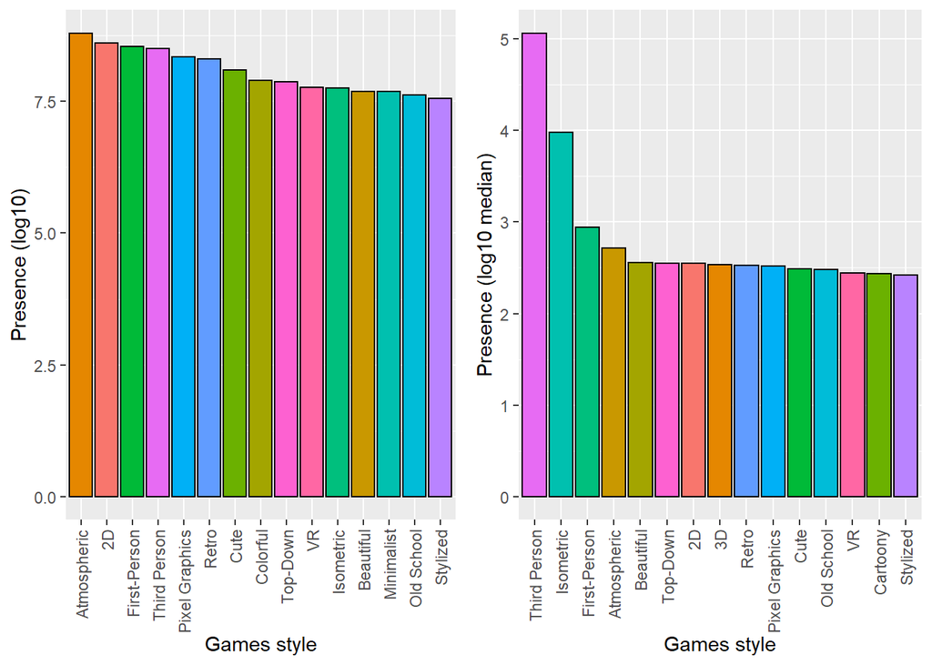

```r
p1<-game_descriptors[,c(1,70:86)] %>%
  binaryGrouping(clean_df) %>%
  arrange(desc(TotalPresence)) %>%
  slice(1:15) %>%
    ggplot(aes(x=reorder(GroupingVar, -TotalPresence), y=log10(TotalPresence), fill=GroupingVar)) +
    geom_bar(colour="black", stat="identity")+
  theme(axis.text.x = element_text(angle = 90, vjust = 0.5, hjust=1), legend.position="none")+
    xlab("Games style") + ylab("Presence (log10)")

p2<-game_descriptors[,c(1,70:86)] %>%
  binaryGrouping(clean_df) %>%
  arrange(desc(MedianPresence)) %>%
  slice(1:15) %>%
    ggplot(aes(x=reorder(GroupingVar, -MedianPresence), y=log10(MedianPresence), fill=GroupingVar)) +
    geom_bar(colour="black", stat="identity")+
  theme(axis.text.x = element_text(angle = 90, vjust = 0.5, hjust=1), legend.position="none")+
    xlab("Games style") + ylab("Presence (log10 median)")

grid.arrange(p1, p2, nrow = 1)
```

#### Other features

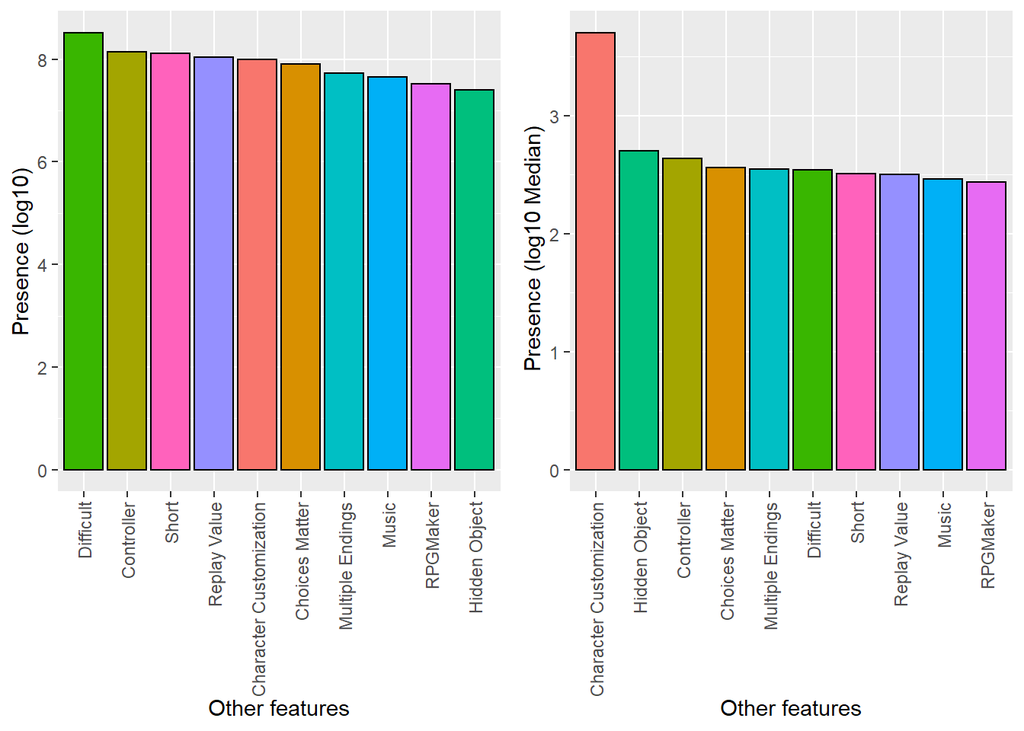

```r
p1<-features %>%
  binaryGrouping(clean_df) %>%
  arrange(desc(TotalPresence)) %>%
  slice(1:15) %>%
    ggplot(aes(x=reorder(GroupingVar, -TotalPresence), y=log10(TotalPresence), fill=GroupingVar)) +
    geom_bar(colour="black", stat="identity")+
  theme(axis.text.x = element_text(angle = 90, vjust = 0.5, hjust=1), legend.position="none")+
    xlab("Other features") + ylab("Presence (log10)")

p2<-features %>%
  binaryGrouping(clean_df) %>%
  arrange(desc(MedianPresence)) %>%
  slice(1:15) %>%
    ggplot(aes(x=reorder(GroupingVar, -MedianPresence), y=log10(MedianPresence), fill=GroupingVar)) +
    geom_bar(colour="black", stat="identity")+
  theme(axis.text.x = element_text(angle = 90, vjust = 0.5, hjust=1), legend.position="none")+
    xlab("Other features") + ylab(" Presence (log10 Median)")

grid.arrange(p1, p2, nrow = 1)
```

#### Rating NAs

Analysing the relation between presence and the rating variables missing values we can see that the games with more NAs are also the ones with more presence:

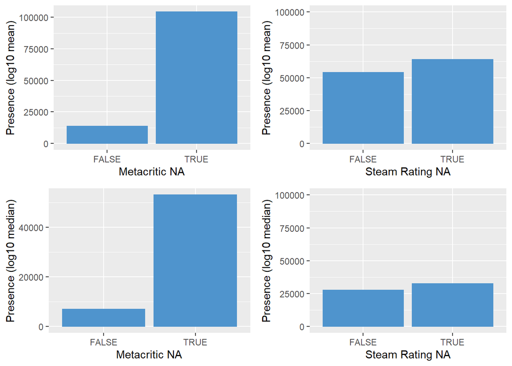

```r
p1<- ggplot(clean_df, aes(x=Metacritic_NA, y=log10(mean(Presence)))) +
    geom_bar(colour="steelblue3", stat="identity")+
    xlab("Metacritic NA") + ylab("Presence (log10 mean)")
p2<- ggplot(clean_df, aes(x=is.na(Steam_Rate), y=log10(mean(Presence)))) +
    geom_bar(colour="steelblue3", stat="identity")+
  coord_cartesian(ylim = c(0, 100000)) +
    xlab("Steam Rating NA") + ylab("Presence (log10 mean)")

p3<- ggplot(clean_df, aes(x=Metacritic_NA, y=log10(median(Presence)))) +
    geom_bar(colour="steelblue3", stat="identity")+
    xlab("Metacritic NA") + ylab("Presence (log10 median)")
p4<- ggplot(clean_df, aes(x=is.na(Steam_Rate), y=log10(median(Presence)))) +
    geom_bar(colour="steelblue3", stat="identity")+
  coord_cartesian(ylim = c(0, 100000)) +
    xlab("Steam Rating NA") + ylab("Presence (log10 median)")
grid.arrange(p1, p2,p3,p4, nrow = 2)
```

### 3.3. Rating

#### Genres

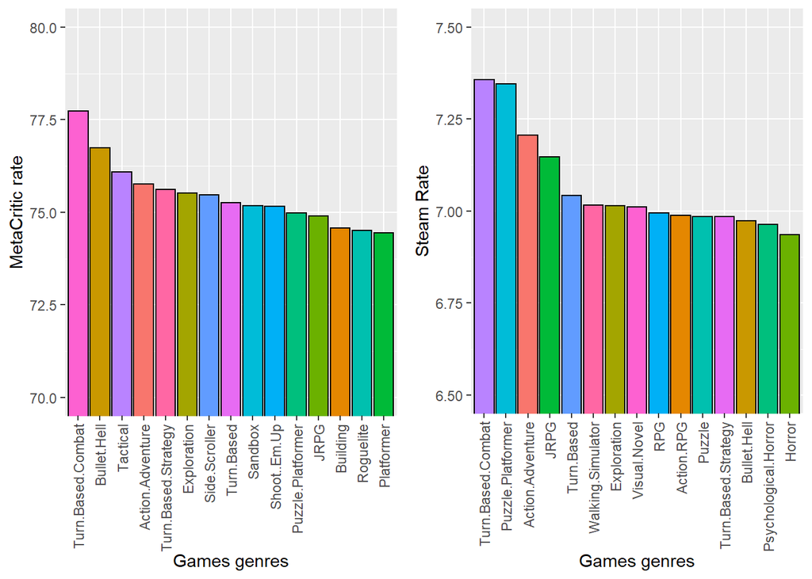

```r
p1<-game_descriptors[,c(1:9,18:54)] %>%
  binaryGrouping(clean_df) %>%
  arrange(desc(critic_mean)) %>%
  slice(1:15) %>%
    ggplot(aes(x=reorder(GroupingVar, -critic_mean), y=critic_mean, fill=GroupingVar)) +
    geom_bar(colour="black", stat="identity")+
  theme(axis.text.x = element_text(angle = 90, vjust = 0.5, hjust=1), legend.position="none")+
coord_cartesian(ylim = c(70, 80)) +
    xlab("Games genres") + ylab("MetaCritic rate")

p2<-game_descriptors[,c(1:9,18:54)] %>%
  binaryGrouping(clean_df) %>%
  arrange(desc(Steam_Rate)) %>%
  slice(1:15) %>%
    ggplot(aes(x=reorder(GroupingVar, -Steam_Rate), y=Steam_Rate, fill=GroupingVar)) +
    geom_bar(colour="black", stat="identity")+
  theme(axis.text.x = element_text(angle = 90, vjust = 0.5, hjust=1), legend.position="none")+
  coord_cartesian(ylim = c(6.5, 7.5)) +
    xlab("Games genres") + ylab("Steam Rate")

grid.arrange(p1, p2, nrow = 1)
```

#### Setting

[figure not shown]

```r
p1<-game_descriptors[,c(1,56:69)] %>%
  binaryGrouping(clean_df) %>%
  arrange(desc(critic_mean)) %>%
  slice(1:15) %>%
    ggplot(aes(x=reorder(GroupingVar, -critic_mean), y=critic_mean, fill=GroupingVar)) +
    geom_bar(colour="black", stat="identity")+
  theme(axis.text.x = element_text(angle = 90, vjust = 0.5, hjust=1), legend.position="none")+
coord_cartesian(ylim = c(70, 80)) +
    xlab("Games setting") + ylab("MetaCritic rate")

p2<-game_descriptors[,c(1,56:69)] %>%
  binaryGrouping(clean_df) %>%
  arrange(desc(Steam_Rate)) %>%
  slice(1:15) %>%
    ggplot(aes(x=reorder(GroupingVar, -Steam_Rate), y=Steam_Rate, fill=GroupingVar)) +
    geom_bar(colour="black", stat="identity")+
  theme(axis.text.x = element_text(angle = 90, vjust = 0.5, hjust=1), legend.position="none")+
  coord_cartesian(ylim = c(6.5, 7.5)) +
    xlab("Games setting") + ylab("Steam Rate")

grid.arrange(p1, p2, nrow = 1)
```

#### Style

[figure not shown]

```r
p1<-game_descriptors[,c(1,70:86)] %>%
  binaryGrouping(clean_df) %>%
  arrange(desc(critic_mean)) %>%
  slice(1:15) %>%
    ggplot(aes(x=reorder(GroupingVar, -critic_mean), y=critic_mean, fill=GroupingVar)) +
    geom_bar(colour="black", stat="identity")+
  theme(axis.text.x = element_text(angle = 90, vjust = 0.5, hjust=1), legend.position="none")+
coord_cartesian(ylim = c(70, 80)) +
    xlab("Games style") + ylab("MetaCritic rate")

p2<-game_descriptors[,c(1,70:86)] %>%
  binaryGrouping(clean_df) %>%
  arrange(desc(Steam_Rate)) %>%
  slice(1:15) %>%
    ggplot(aes(x=reorder(GroupingVar, -Steam_Rate), y=Steam_Rate, fill=GroupingVar)) +
    geom_bar(colour="black", stat="identity")+
  theme(axis.text.x = element_text(angle = 90, vjust = 0.5, hjust=1), legend.position="none")+
  coord_cartesian(ylim = c(6.5, 7.5)) +
    xlab("Games style") + ylab("Steam Rate")

grid.arrange(p1, p2, nrow = 1)
```

#### Other features

[figure not shown]

```r
p1<-features %>%
  binaryGrouping(clean_df) %>%
  arrange(desc(critic_mean)) %>%
  slice(1:15) %>%
    ggplot(aes(x=reorder(GroupingVar, -critic_mean), y=critic_mean, fill=GroupingVar)) +
    geom_bar(colour="black", stat="identity")+
  theme(axis.text.x = element_text(angle = 90, vjust = 0.5, hjust=1), legend.position="none")+
coord_cartesian(ylim = c(70, 80)) +
    xlab("Other features") + ylab("MetaCritic rate")

p2<-features %>%
  binaryGrouping(clean_df) %>%
  arrange(desc(Steam_Rate)) %>%
  slice(1:15) %>%
    ggplot(aes(x=reorder(GroupingVar, -Steam_Rate), y=Steam_Rate, fill=GroupingVar)) +
    geom_bar(colour="black", stat="identity")+
  theme(axis.text.x = element_text(angle = 90, vjust = 0.5, hjust=1), legend.position="none")+
  coord_cartesian(ylim = c(6, 8)) +
    xlab("Other features") + ylab("Steam Rate")

grid.arrange(p1, p2, nrow = 1)
```

## 4. Insights

In this project we have prepared the Steam Games 2020 dataset for it analysis. We also made some visualizations to understand a bit better the data we are working with. We can extract some initial inisghts about the data:

- By far, there are more Action and Adventure games than other genres
  - So, these are also the categories with more presence
  - but when we check the median presence per category, we can see how these categories are not even in the top 10 categories
  - This point a bias due to the amount of games in the genres and/or some games with a extremly high presence in the main genres
  - In both Metacritic and Steam Rating system, Turn based Combat games are the best rated.
- The most played setting are Open World games
  - while the best rated are Classical games.
  - There are differences between Metacritic and Steam rates  
    *,It is also interesting to point out how the Presence appears to be different in games rated or not rated at Metacritic or Steam: unrated games have a higher presence